# Stats 506, F18, Problem Set 3

Ruirui Zhang, ruiruiz@umich.edu

### Question 1:

First, repeat question 3 parts a-c from problem set 1 using data.table for all computations and data manipulations.

Then, formulate and state a question answerable using the RECS data. Your question should be similar in scope to (one of) parts a-c above and should rely on one or more variables not previously used. Answer your question (using data.table) and provide supporting evidence in the form of nicely formatted graphs and/or tables.

### Question 1-a:

### Question 3a:

What percent of homes have stucco construction as the major outside wall material within each division? Which division has the highest proportion? Which the lowest?

### Answer 1-a:

Proportion of homes with stucco construction within each census division in 2015. Estimates are based on the residential energy consumption survey.

| Census Division | % Stucco Homes (95% CI) |
| --- | --- |
| Mountain South | 64.2% (55.4, 73.0) |
| Pacific | 44.6% (41.3, 47.9) |
| Mountain North | 16.6% (10.2, 23.0) |
| South Atlantic | 10.6% ( 7.8, 13.4) |
| West North Central | 4.9% ( 0.9, 8.8) |
| West South Central | 3.0% ( 1.6, 4.3) |
| Middle Atlantic | 2.1% ( 0.6, 3.5) |
| New England | 1.2% (-0.3, 2.8) |
| East North Central | 0.7% ( 0.1, 1.2) |
| East South Central | 0.4% (-0.4, 1.2) |

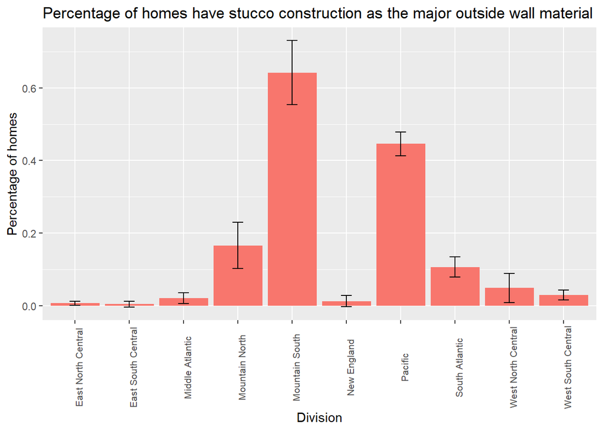

### Question 1-b:

What is average total electricity usage in kilowatt hours in each division? Answer the same question stratified by urban and rural status.

### Answer 1-b:

Average annual electricity utilization by Census Division in kwh/home.

[output not shown]

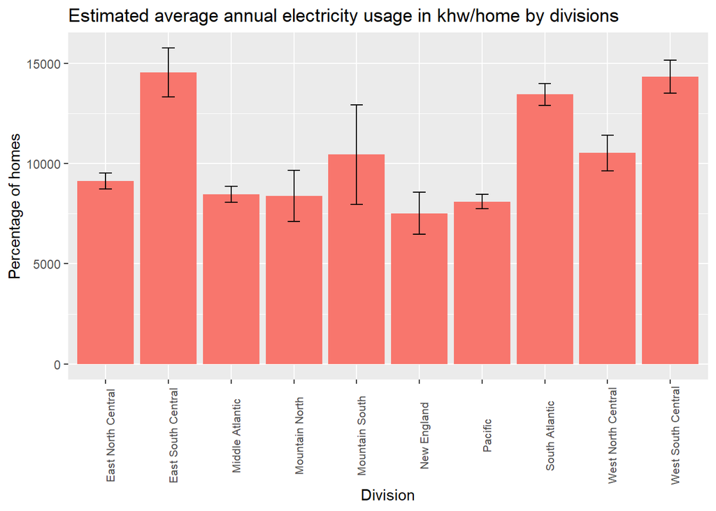

Average annual electricity utilization by Census Division in kwh/home for rural areas.

[output not shown]

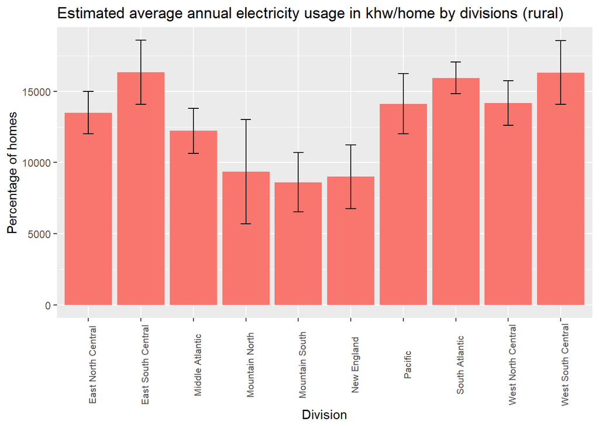

Average annual electricity utilization by Census Division in kwh/home for urban areas.

[output not shown]

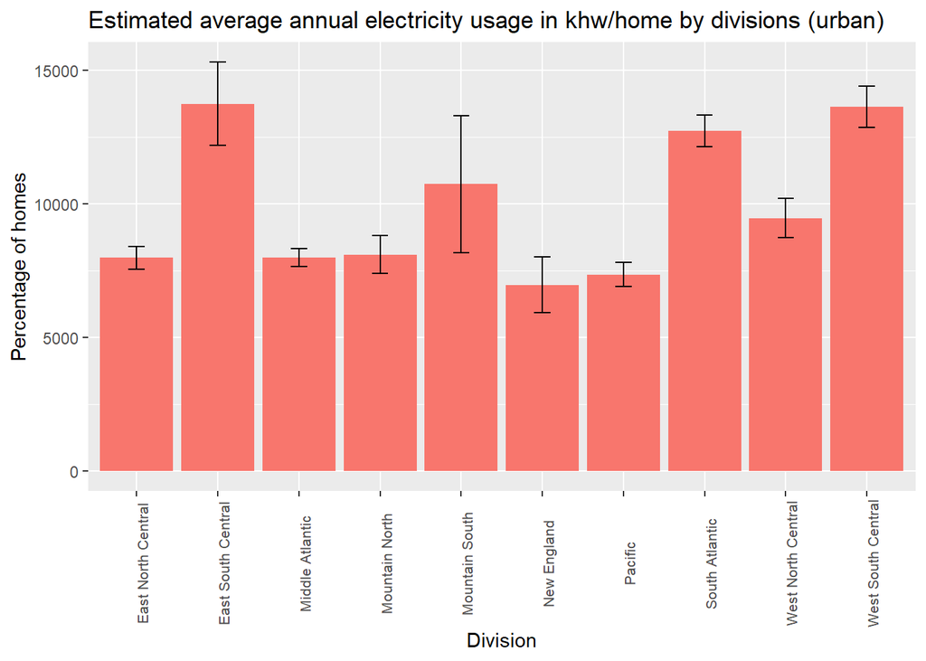

### Question 1c

Which division has the largest disparity between urban and rural areas in terms of the proportion of homes with Internet access?

### Answer 1c:

Urban and rural disparity in internet access for the ten US Census Division in 2015.

[output not shown]

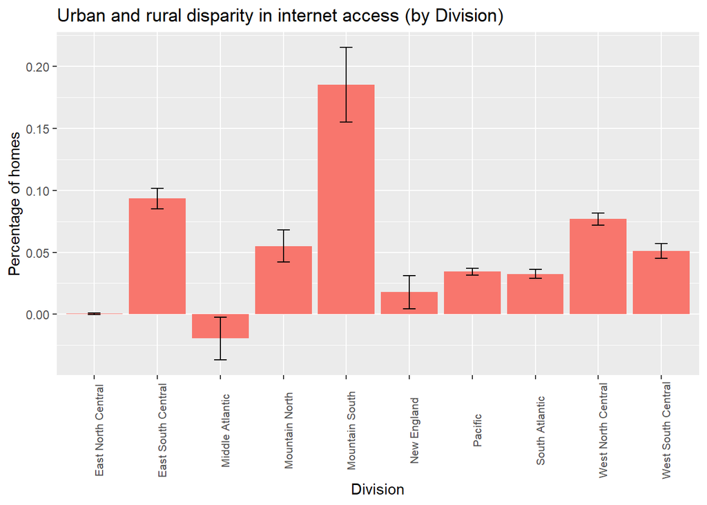

### Question 1d:

Formulate and state a question answerable using the RECS data. Your question should be similar in scope to (one of) parts a-c above and should rely on one or more variables not previously used. Answer your question(using data.table) and provide supporting evidence in the form of nicely formatted graphs and/or tables.

### Answer 1d:

Question:

Which division has the largest disparity between urban and rural areas in terms of the proportion of having laptop at home?

Answer:

Urban and rural disparity in having laptop at home for the ten US Census Division in 2015.

[output not shown]

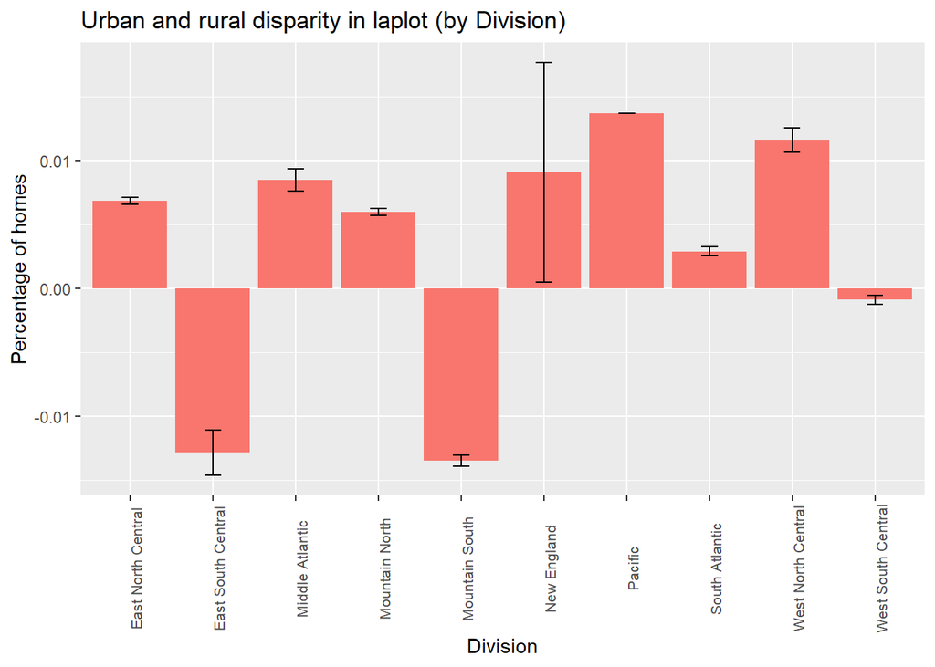